## Agenda

Use `dplyr` to:

- select variables/columns
- filter data
- arrange data
- generate new variables
- grouped summaries

## Introduction

According to a [survey](http://visit.crowdflower.com/rs/416-ZBE-142/images/CrowdFlower_DataScienceReport_2016.pdf) by [CrowdFlower](https://www.crowdflower.com/), data scientists spend most of their time cleaning and manipulating data rather than mining or modeling them for insights. As such, it becomes important to have tools that make data manipulation faster and easier. In today’s post, we introduce you to [dplyr](http://dplyr.tidyverse.org/), a grammar of data manipulation.

[figure not shown]

## Why dplyr

dplyr helps us solve the most common data manipulation challenges such as filtering rows, selecting columns, sorting data, creating new columns, summarizing data etc. In order to truly appreciate dplyr, we will compare it to the functions in base R.

## Libraries

```r
library(dplyr)
library(readr)
```

## dplyr Verbs

dplyr provides a set of verbs that help us solve the most common data manipulation challenges while working with tabular data (dataframes, tibbles):

- `select`: returns subset of columns
- `filter`: returns a subset of rows
- `arrange`: re-order or arrange rows according to single/multiple variables
- `mutate`: create new columns from existing columns
- `summarise`: reduce data to a single summary

## Case Study

We will explore dummy data that we have created to resemble web logs of a ecommerce company. You can download the data from [here](https://github.com/rsquaredacademy/datasets/blob/master/web.csv) or import it directly using `read_csv()` from the readr package. We will use dplyr to answer a few questions we have about the above data:

- what is the average order value by device types?
- what is the average number of pages visited by purchasers and non-purchasers?
- what is the average time on site for purchasers vs non-purchasers?
- what is the average number of pages visited by purchasers and non-purchasers using mobile?

## Data

```r
ecom <- read_csv('data/web.csv')
```

```
## # A tibble: 1,000 x 11
##       id referrer device bouncers n_visit n_pages duration country
##    <int> <chr>    <chr>  <chr>      <int>   <dbl>    <dbl> <chr>
##  1     1 google   laptop true          10    1.00    693   Czech Republic
##  2     2 yahoo    tablet true           9    1.00    459   Yemen
##  3     3 direct   laptop true           0    1.00    996   Brazil
##  4     4 bing     tablet false          3   18.0     468   China
##  5     5 yahoo    mobile true           9    1.00    955   Poland
##  6     6 yahoo    laptop false          5    5.00    135   South Africa
##  7     7 yahoo    mobile true          10    1.00     75.0 Bangladesh
##  8     8 direct   mobile true          10    1.00    908   Indonesia
##  9     9 bing     mobile false          3   19.0     209   Netherlands
## 10    10 google   mobile true           6    1.00    208   Czech Republic
## # ... with 990 more rows, and 3 more variables: purchase <chr>,
## #   order_items <dbl>, order_value <dbl>
```

## Average Order Value

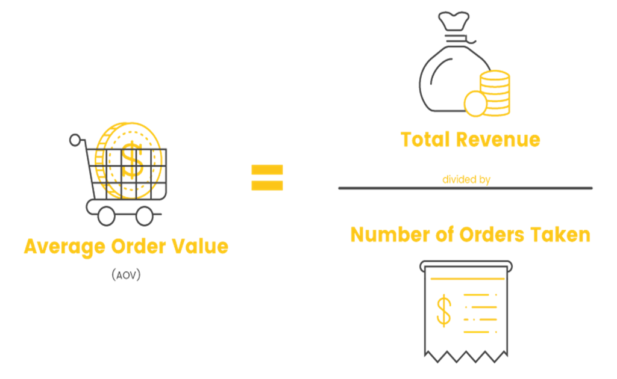

## AOV by Devices

```r
ecom %>%
  filter(purchase == 'true') %>%
  select(device, order_value, order_items) %>%
  group_by(device) %>%
  summarise_all(funs(sum)) %>%
  mutate(
    aov = order_value / order_items
  ) %>%
  select(device, aov)
```

```
## # A tibble: 3 x 2
##   device   aov
##   <chr>  <dbl>
## 1 laptop   353
## 2 mobile   280
## 3 tablet   261
```

## Step 1: Filter Purchasers

In order to compute the AOV, we must first separate the purchasers from non-purchasers. We will do this by filtering the data related to purchasers using the `filter()` function. It allows us to filter rows that meet a specific criteria/condition. The first argument is the name of the data frame and the rest of the arguments are expressions for filtering the data. Let us look at a few examples:

## Select all visits from mobile

```r
filter(ecom, device == "mobile")
```

```
## # A tibble: 344 x 11
##       id referrer device bouncers n_visit n_pages duration country
##    <int> <chr>    <chr>  <chr>      <int>   <dbl>    <dbl> <chr>
##  1     5 yahoo    mobile true           9    1.00    955   Poland
##  2     7 yahoo    mobile true          10    1.00     75.0 Bangladesh
##  3     8 direct   mobile true          10    1.00    908   Indonesia
##  4     9 bing     mobile false          3   19.0     209   Netherlands
##  5    10 google   mobile true           6    1.00    208   Czech Republic
##  6    13 direct   mobile false          9   14.0     406   Ireland
##  7    15 yahoo    mobile false          7    1.00     19.0 France
##  8    22 google   mobile true           5    1.00    147   Brazil
##  9    23 bing     mobile false          0    7.00    196   Russia
## 10    29 google   mobile true          10    1.00    338   Russia
## # ... with 334 more rows, and 3 more variables: purchase <chr>,
## #   order_items <dbl>, order_value <dbl>
```

## visits from mobile that converted

```r
filter(ecom, device == "mobile", purchase == "true")
```

```
## # A tibble: 36 x 11
##       id referrer device bouncers n_visit n_pages duration country
##    <int> <chr>    <chr>  <chr>      <int>   <dbl>    <dbl> <chr>
##  1    13 direct   mobile false          9    14.0      406 Ireland
##  2    41 bing     mobile false          4    20.0      440 Czech Republic
##  3    98 bing     mobile false          3    18.0      288 Portugal
##  4   112 social   mobile false         10    11.0      242 Argentina
##  5   125 yahoo    mobile false          6    14.0      322 China
##  6   134 google   mobile false          1    18.0      252 Indonesia
##  7   143 social   mobile false          7    16.0      352 Sweden
##  8   156 direct   mobile false          4    18.0      324 China
##  9   219 social   mobile false          1    20.0      520 United States
## 10   227 yahoo    mobile false          0    13.0      351 United States
## # ... with 26 more rows, and 3 more variables: purchase <chr>,
## #   order_items <dbl>, order_value <dbl>
```

## from mobile & visited > 5 pages

```r
filter(ecom, device == "mobile", n_pages > 5)
```

```
## # A tibble: 139 x 11
##       id referrer device bouncers n_visit n_pages duration country
##    <int> <chr>    <chr>  <chr>      <int>   <dbl>    <dbl> <chr>
##  1     9 bing     mobile false          3   19.0       209 Netherlands
##  2    13 direct   mobile false          9   14.0       406 Ireland
##  3    23 bing     mobile false          0    7.00      196 Russia
##  4    30 yahoo    mobile false          8    9.00      225 Colombia
##  5    41 bing     mobile false          4   20.0       440 Czech Republic
##  6    42 direct   mobile false          1   13.0       234 Indonesia
##  7    89 direct   mobile false          4    8.00      144 Ecuador
##  8    92 google   mobile false          5    8.00      192 Indonesia
##  9    98 bing     mobile false          3   18.0       288 Portugal
## 10   112 social   mobile false         10   11.0       242 Argentina
## # ... with 129 more rows, and 3 more variables: purchase <chr>,
## #   order_items <dbl>, order_value <dbl>
```

## Case Study: visits that converted

```r
filter(ecom, purchase == "true")
```

```
## # A tibble: 103 x 11
##       id referrer device bouncers n_visit n_pages duration country
##    <int> <chr>    <chr>  <chr>      <int>   <dbl>    <dbl> <chr>
##  1     4 bing     tablet false          3    18.0      468 China
##  2    13 direct   mobile false          9    14.0      406 Ireland
##  3    17 bing     tablet false          5    16.0      368 Peru
##  4    19 social   tablet false          7    10.0      290 Colombia
##  5    27 direct   tablet false          2    19.0      342 Japan
##  6    34 social   tablet false          9    20.0      420 Indonesia
##  7    41 bing     mobile false          4    20.0      440 Czech Republic
##  8    94 yahoo    tablet false          2    16.0      480 China
##  9    98 bing     mobile false          3    18.0      288 Portugal
## 10   101 yahoo    tablet false          2    14.0      364 Poland
## # ... with 93 more rows, and 3 more variables: purchase <chr>,
## #   order_items <dbl>, order_value <dbl>
```

## Step 2: Select relevant columns

After filtering the data, we need to select relevent variables to compute the AOV. Remember, we do not need all the columns in the data to compute a required metric (in our case, AOV). The `select()` function allows us to select a subset of columns. The first argument is the name of the data frame and the subsequent arguments specify the columns by name or position. Let us look at a few examples:

## Select device and purchase columns

```r
select(ecom, device, purchase)
```

```
## # A tibble: 1,000 x 2
##    device purchase
##    <chr>  <chr>
##  1 laptop false
##  2 tablet false
##  3 laptop false
##  4 tablet true
##  5 mobile false
##  6 laptop false
##  7 mobile false
##  8 mobile false
##  9 mobile false
## 10 mobile false
## # ... with 990 more rows
```

## all columns from device to purchase

```r
select(ecom, device:purchase)
```

```
## # A tibble: 1,000 x 7
##    device bouncers n_visit n_pages duration country        purchase
##    <chr>  <chr>      <int>   <dbl>    <dbl> <chr>          <chr>
##  1 laptop true          10    1.00    693   Czech Republic false
##  2 tablet true           9    1.00    459   Yemen          false
##  3 laptop true           0    1.00    996   Brazil         false
##  4 tablet false          3   18.0     468   China          true
##  5 mobile true           9    1.00    955   Poland         false
##  6 laptop false          5    5.00    135   South Africa   false
##  7 mobile true          10    1.00     75.0 Bangladesh     false
##  8 mobile true          10    1.00    908   Indonesia      false
##  9 mobile false          3   19.0     209   Netherlands    false
## 10 mobile true           6    1.00    208   Czech Republic false
## # ... with 990 more rows
```

## all columns excluding id and country

```r
select(ecom, -id, -country)
```

```
## # A tibble: 1,000 x 9
##    referrer device bouncers n_visit n_pages duration purchase order_items
##    <chr>    <chr>  <chr>      <int>   <dbl>    <dbl> <chr>          <dbl>
##  1 google   laptop true          10    1.00    693   false           0
##  2 yahoo    tablet true           9    1.00    459   false           0
##  3 direct   laptop true           0    1.00    996   false           0
##  4 bing     tablet false          3   18.0     468   true            6.00
##  5 yahoo    mobile true           9    1.00    955   false           0
##  6 yahoo    laptop false          5    5.00    135   false           0
##  7 yahoo    mobile true          10    1.00     75.0 false           0
##  8 direct   mobile true          10    1.00    908   false           0
##  9 bing     mobile false          3   19.0     209   false           0
## 10 google   mobile true           6    1.00    208   false           0
## # ... with 990 more rows, and 1 more variable: order_value <dbl>
```

## Case Study: Select

For our case study, we need to select the columns order value and order items to calculate the AOV. We also need to select the device column as we are computing the AOV for different devices.

```r
select(ecom, device, order_value, order_items)
```

```
## # A tibble: 1,000 x 3
##    device order_value order_items
##    <chr>        <dbl>       <dbl>
##  1 laptop           0        0
##  2 tablet           0        0
##  3 laptop           0        0
##  4 tablet         434        6.00
##  5 mobile           0        0
##  6 laptop           0        0
##  7 mobile           0        0
##  8 mobile           0        0
##  9 mobile           0        0
## 10 mobile           0        0
## # ... with 990 more rows
```

## Case Study: Select

But we want the above data only for purchasers. We will combine `filter()` and `select()` functions to extract data related to purchasers.

```r
ecom1 <- filter(ecom, purchase == "true")
ecom2 <- select(ecom1, device, order_value, order_items)
ecom2
```

```
## # A tibble: 103 x 3
##    device order_value order_items
##    <chr>        <dbl>       <dbl>
##  1 tablet         434        6.00
##  2 mobile         651        3.00
##  3 tablet        1049        6.00
##  4 tablet        1304        9.00
##  5 tablet         622        5.00
##  6 tablet        1613        7.00
##  7 mobile         184        3.00
##  8 tablet         286        9.00
##  9 mobile         764        6.00
## 10 tablet        1667        6.00
## # ... with 93 more rows
```

## Step 3: Group data by devices

Since we want to compute the AOV for each device, we need to compute the total order value and total order items for each device. To achieve this, we will group the selected variables by device type. Using the `group_by()` function, we will group our case study data by device types. The first argument is the name of the data frame and the second argument is the name of the column based on which the data will be split. Let us look at a few examples:

## Group data by referrer type

```r
group_by(ecom, referrer)
```

```
## # A tibble: 1,000 x 11
## # Groups:   referrer [5]
##       id referrer device bouncers n_visit n_pages duration country
##    <int> <chr>    <chr>  <chr>      <int>   <dbl>    <dbl> <chr>
##  1     1 google   laptop true          10    1.00    693   Czech Republic
##  2     2 yahoo    tablet true           9    1.00    459   Yemen
##  3     3 direct   laptop true           0    1.00    996   Brazil
##  4     4 bing     tablet false          3   18.0     468   China
##  5     5 yahoo    mobile true           9    1.00    955   Poland
##  6     6 yahoo    laptop false          5    5.00    135   South Africa
##  7     7 yahoo    mobile true          10    1.00     75.0 Bangladesh
##  8     8 direct   mobile true          10    1.00    908   Indonesia
##  9     9 bing     mobile false          3   19.0     209   Netherlands
## 10    10 google   mobile true           6    1.00    208   Czech Republic
## # ... with 990 more rows, and 3 more variables: purchase <chr>,
## #   order_items <dbl>, order_value <dbl>
```

## Case Study: Group

In the second line in the previous output, you can observe `Groups: referrer [5]`. The data is split into 5 groups as the referrer variable has 5 distinct values. For our case study, we need to group the data by device type.

```r
ecom3 <- group_by(ecom2, device)
ecom3
```

```
## # A tibble: 103 x 3
## # Groups:   device [3]
##    device order_value order_items
##    <chr>        <dbl>       <dbl>
##  1 tablet         434        6.00
##  2 mobile         651        3.00
##  3 tablet        1049        6.00
##  4 tablet        1304        9.00
##  5 tablet         622        5.00
##  6 tablet        1613        7.00
##  7 mobile         184        3.00
##  8 tablet         286        9.00
##  9 mobile         764        6.00
## 10 tablet        1667        6.00
## # ... with 93 more rows
```

## Step 4: Total order value and order items

The next step is to compute the total order value and total order items for each device. We will use them to then compute the average order value. Now we need to reduce the order value and order items data to a single summary. We can achieve this using the `summarise()` function. The first argument is the name of a data frame and the subsequent arguments are functions that can generate a summary. For example, we can use `min`, `max`, `sum`, `mean` etc.

## Summarise

For our case study, we need the totals of order value and order items. What function can we use to obtain them? The `sum()` function will generate the sum of the values and hence we will use it inside the `summarise()` function. Remember, we need to provide a name to the summary being generated.

```r
ecom4 <- summarise(ecom3, total_value = sum(order_value),
          total_items = sum(order_items))
ecom4
```

```
## # A tibble: 3 x 3
##   device total_value total_items
##   <chr>        <dbl>       <dbl>
## 1 laptop       56531         160
## 2 mobile       51504         184
## 3 tablet       51321         197
```

## Summarise

There you go, we have the total order value and total order items for each device type. Another way to achieve the above result is to use the `summarise_all()` function. How does that work? It generates the specified summary for all the columns in the data set except for the column based on which the data has been grouped. So we need to ensure that the data frame does not have any irrelevant columns.

## Case Study: Summarise

In our case study, we have split the data based on the device type and we have 2 other columns which are order value and order items. If we use `summarise_all()` function, it will generate the summary for the two columns based on the function specified. To specify the functions, we need to use another argument `funs` and it can take any number of valid functions.

```r
ecom4 <- summarise_all(ecom3, funs(sum))
ecom4
```

```
## # A tibble: 3 x 3
##   device order_value order_items
##   <chr>        <dbl>       <dbl>
## 1 laptop       56531         160
## 2 mobile       51504         184
## 3 tablet       51321         197
```

## Step 5: Compute AOV

Now that we have the total order value and total order items for each device category, we can compute the AOV. We will create a new column to store the result. To create a new column, we will use the `mutate()` function. The first argument is the name of the data frame and the subsequent arguments are expressions for creating new columns based out of existing columns.

```r
ecom5 <- mutate(ecom4, aov = order_value / order_items)
ecom5
```

```
## # A tibble: 3 x 4
##   device order_value order_items   aov
##   <chr>        <dbl>       <dbl> <dbl>
## 1 laptop       56531         160   353
## 2 mobile       51504         184   280
## 3 tablet       51321         197   261
```

## Step 6: Select relevant columns

The last step is to select the relevant columns. We require the device type and the corresponding aov and hence we can get rid of other columns. Use the `select()` function to extract the relevant columns.

```r
ecom6 <- select(ecom5, device, aov)
ecom6
```

```
## # A tibble: 3 x 2
##   device   aov
##   <chr>  <dbl>
## 1 laptop   353
## 2 mobile   280
## 3 tablet   261
```

## AOV by Devices

Let us combine all the code from the above steps:

```r
ecom1 <- filter(ecom, purchase == "true")
ecom2 <- select(ecom1, device, order_value, order_items)
ecom3 <- group_by(ecom2, device)
ecom4 <- summarise_all(ecom3, funs(sum))
ecom5 <- mutate(ecom4, aov = order_value / order_items)
ecom6 <- select(ecom5, device, aov)
ecom6
```

```
## # A tibble: 3 x 2
##   device   aov
##   <chr>  <dbl>
## 1 laptop   353
## 2 mobile   280
## 3 tablet   261
```

## AOV by Devices

If you observe, at each step we create a new variable(data frame) and then use it as an input in the next step i.e. the output from one function becomes the input for another function. Can we achieve the final outcome i.e. `ecom6` without creating the intermediate data frames (ecom1 - ecom5)? Yes, we can. We will use the `%>%` operator to chain the above steps so that we can avoid creating the intermediate data frames. Let us see how to do that.

## AOV by Devices

```r
ecom %>%
  filter(purchase == 'true') %>%
  select(device, order_value, order_items) %>%
  group_by(device) %>%
  summarise_all(funs(sum)) %>%
  mutate(
    aov = order_value / order_items
  ) %>%
  select(device, aov)
```

```
## # A tibble: 3 x 2
##   device   aov
##   <chr>  <dbl>
## 1 laptop   353
## 2 mobile   280
## 3 tablet   261
```

## Practice Questions

- what is the average number of pages visited by purchasers and non-purchasers?
- what is the average time on site for purchasers vs non-purchasers?
- what is the average number of pages visited by purchasers and non-purchasers using mobile?